# Introduction to Statistical Learning

## Where we left off

- **Part I (Days 1-8):** getting data into shape
  - wrangle it, plot it, clean it, engineer features
- **Part II (today on):** using that data to **learn something**
  - predict an outcome, or explain what drives it
- Day 8 ended with a warning:
  - *“With enough invented variables, something will look predictive by chance. We’ll make this precise when we cover overfitting.”*
- **Today we make it precise.**

## 1. What is statistical learning?

## The setup

We observe an outcome \(Y\) and some inputs \(X = (X_1, \dots, X_p)\), and assume

\[Y = f(X) + \varepsilon\]

| Piece | Name(s) | In the Auto example |
| --- | --- | --- |
| *Y* | response, outcome, dependent variable | `mpg` |
| *X* | predictors, features, inputs | `horsepower` |
| *f* | the systematic part — **unknown** | how mileage really depends on power |
| *ε* | error: everything else, mean zero | driver habits, tires, measurement |

**Statistical learning** = the set of methods for estimating \(f\). We call the estimate \(\hat f\), and its predictions \(\hat Y = \hat f(X)\).

## What \(f\) and \(\varepsilon\) look like

> **How does a car’s mileage depend on its horsepower?** That dependence is \(f\).

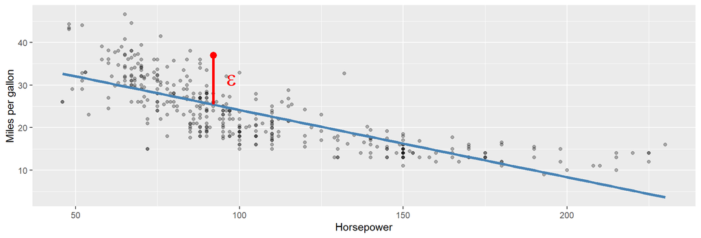

**Blue:** our estimate of \(f\). **Red:** one car’s \(\varepsilon\), a Datsun 510 that gets 11.6 mpg more than the line predicts.

## Why estimate \(f\)? Two different goals

**Prediction:** you need a good \(\hat Y\); \(\hat f\) can be a black box.

- Will this borrower default? Which customers will cancel next month?

**Inference:** you need to know *how* \(Y\) depends on each \(X\).

- How much does an extra year of schooling raise wages?
- Does horsepower cost imports more mileage? *(Day 8’s interaction)*

Most economics is inference; most industry data science is prediction. The goal decides the method.

## Flexibility vs. interpretability

**Flexibility** = how many different shapes a method can take.

| Method | Flexibility | Interpretability | We cover it |
| --- | --- | --- | --- |
| Linear / logistic regression | low | high | Days 10-12 |
| Decision trees | medium | medium | Days 15-16 |
| KNN, random forests, boosting | high | low | Days 13, 17-18 |

- For **inference**, you usually want the interpretable end: a coefficient you can explain.
- For **prediction**, it’s tempting to reach for the most flexible method.
- **Today’s punchline:** more flexible is *not* automatically more accurate, even when prediction is all you care about.

## The vocabulary of the rest of the course

**Supervised** learning: we observe \(Y\) for each case, and learn to predict it.

- **Regression:** \(Y\) is a number (wage, mpg, price).
- **Classification:** \(Y\) is a category (default / no default, spam / not spam).

**Unsupervised** learning: no \(Y\) at all. Look for structure in \(X\) alone.

- **Clustering:** group similar customers, products, counties (Days 19-20).
- **Dimension reduction:** summarize 50 variables in 2 or 3 (PCA, Day 21).

*Quick check:* predicting whether a firm goes bankrupt next year — which kind? Grouping 300 stocks by how their returns move together — which kind?

## 2. How do we know a model is good?

## Scoring a fit: mean squared error

To say whether a model is good, we need a score for how far off it is.

- For each observation, the **miss** is \(y_i - \hat f(x_i)\): that point’s \(\varepsilon_i\), as best our model can tell.
- Square the misses and average them:

\[\text{MSE} = \frac{1}{n}\sum_{i=1}^{n} \big(y_i - \hat f(x_i)\big)^2\]

- Lower is better. Squaring stops + and − misses from cancelling.

**So if we shrink the misses, do we shrink \(\varepsilon\)?**

## Can we make \(\varepsilon\) smaller?

Fit a line and a very flexible curve to 20 cars. Red: each car’s miss.

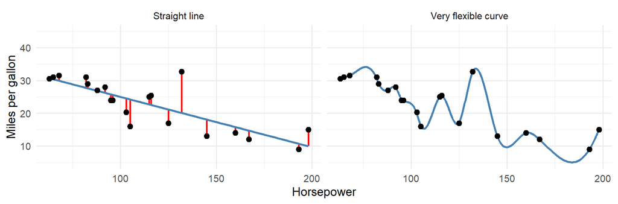

The misses all but vanish: MSE 18.2 for the line, 0.04 for the curve. **Did we just eliminate \(\varepsilon\)?**

## Check it on cars it hasn’t seen

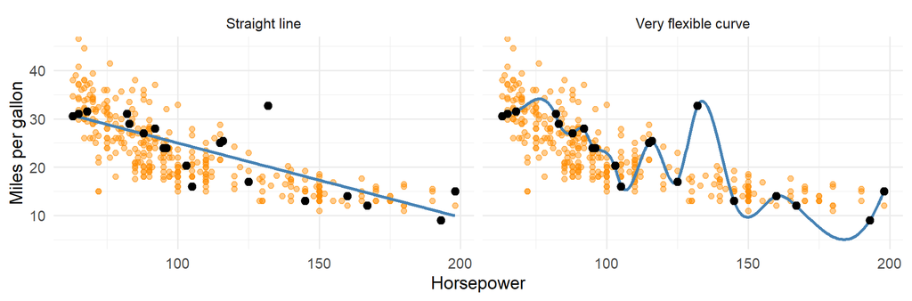

On the new cars, the flexible curve is **worse**: MSE 36.6 vs. 23.9 for the line. The spike near 130 hp fits one car’s \(\varepsilon\). A new car there has a different \(\varepsilon\).

## What just happened

**No, we didn’t eliminate \(\varepsilon\).** The curve **memorized** the \(\varepsilon\) of these 20 cars, and new cars have their own.

Each miss has two parts:

- **Reducible:** \(\hat f\) isn’t the true \(f\). A better model can shrink this.
- **Irreducible:** \(\varepsilon\). No model can shrink this.

So score a model on data it hasn’t seen:

- **Training MSE:** on the data used to fit \(\hat f\). Rewards memorizing.
- **Test MSE:** on new data. *This is the one that matters.*

## A dial for flexibility: polynomial degree

To study this, we need a way to turn flexibility up one notch at a time.

\[\text{mpg} = \beta_0 + \beta_1\,\text{hp} + \beta_2\,\text{hp}^2 + \dots + \beta_d\,\text{hp}^d\]

- **Degree** \(d\) = the highest power of horsepower in the model.
- \(d = 1\) is a straight line; each extra power adds a bend.

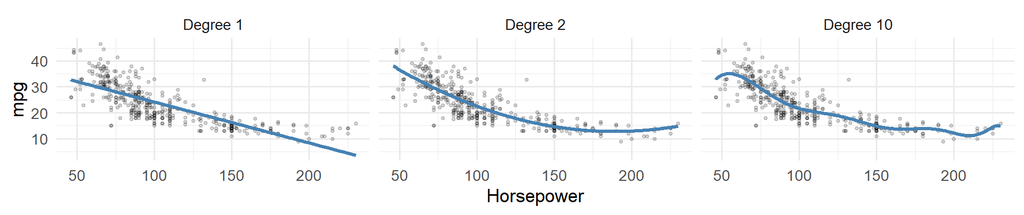

## Training vs. test MSE, degrees 1 to 10

Fit each degree on a random half of the cars; score it on the other half.

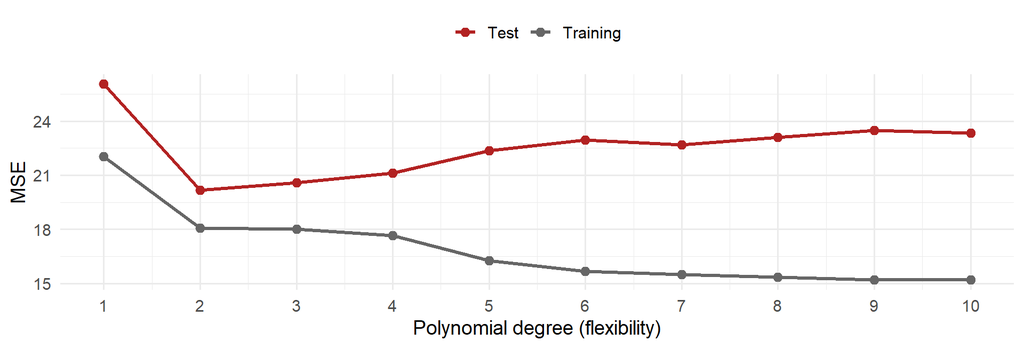

- **Overfitting:** past degree 2, flexibility helps training MSE but hurts test MSE.
- Test MSE tells us *which* model wins. **Bias-variance** tells us *why*.

## 3. The bias-variance trade-off

## A thought experiment

Say we predict a 5C student’s GPA from hours studied.

- **Population:** all 5C students. The true \(f\) lives here.
- **One training set:** this semester’s ECON 122 class, which gives one \(\hat f\).
- Next semester’s class is a **different draw**, so it gives a different \(\hat f\).

Now imagine fitting the same method every semester, for many semesters:

- **Bias:** how far the *average* \(\hat f\) is from the true \(f\).
- **Variance:** how much the \(\hat f\)’s *disagree* from semester to semester.

Both describe the **method across many draws**, not one fitted model.

## Seeing it: a world where we know \(f\)

Simulated truth (dashed); fits from **30 training sets** of 20 points each:

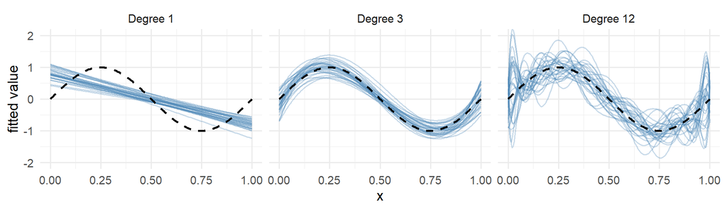

- **Degree 1:** all agree, all miss. **High bias, low variance.**
- **Degree 3:** agree and track the truth. **Low bias, low variance.**
- **Degree 12:** right on average, each chases noise. **Low bias, high variance.**

## Test error = bias² + variance + irreducible

At a new point \(x_0\), averaging over training sets:

\[E\big[(y_0 - \hat f(x_0))^2\big] = \text{Bias}\big[\hat f(x_0)\big]^2 + \text{Var}\big[\hat f(x_0)\big] + \text{Var}(\varepsilon)\]

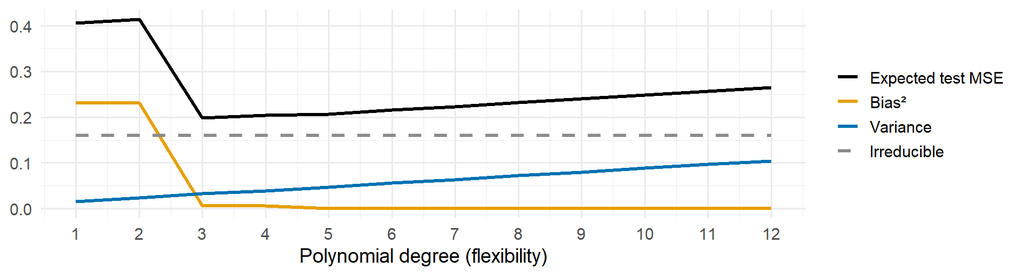

Bias² collapses by degree 3; after that, flexibility buys **only** variance. Best: degree 3.

## Summary

**Statistical learning:** estimate \(f\) in \(Y = f(X) + \varepsilon\), for **prediction** or **inference**.

**Is a model good?**

- Judge it by **test** MSE. Training MSE always falls as flexibility grows.
- **Overfitting:** better training fit, worse test fit.
- No model can remove \(\varepsilon\).

**Bias-variance:** Test MSE = Bias² + Variance + Var(\(\varepsilon\))

- **Bias:** the average fit misses \(f\). **Variance:** the fit changes across training sets.
- The best flexibility is where the sum is smallest.

## For rest of class

- Work on the `day9_activity`
  - you’ll see overfitting on real wage data, then produce the bias and variance yourself by drawing your own training sets
- Ask me questions if you run into issues